# Mini_Project

#### Author: Shruti Gupta

#### File Name: Shruti Gupta - Mini Project - Week 10 Mini Project

#### Date: 04/05/2019

## Data Cleaning and Exploratory Analysis

In machine learning, you clean up the data and turn raw data into features from which you can derive the pattern. There are methods available to extract features that will be covered in upcoming sessions but it's very important to build the intuition. The process of data cleaning and visualization helps with that. In this assignment, we will try to manually identify the important features in the given dataset.

### Dataset: Lending Club data

Years of data to download: 2007-2011

Load the Lending Club data into a pandas dataframe. The data contains 42538 rows and 145 columns. Not all these columns contain meaningful (or any) information so they need to be cleaned. The loans are categorized into different grades and sub-grades. It would be interesting to see whether they have any impact on the interest rates or not. The process should lead us into default prediction, and finding the columns that directly predict how the loan will behave. These would be our most important features.

We strongly recommend that you look in to the columns closely to see the relationship between them. This is not a guided assignment and you can use the techniques that you have learnt so far to clean and visualize the data.

There is no one right answer but this tests your ability to handle a much larger unknown dataset.

Here are the broad guidelines:

```
View the data
Find the columns that are useful (may be null columns) and the ones that are not
Delete the columns that are not needed
Clean columns values like int_rate and term by removing the string part and convert the column to numeric.
Identify the columns containing useful information, they would be the features.
Visualize the important features
```

#### Importing the libraries that are required

```python
import pandas as pd
import numpy as np
import datetime as dt
import matplotlib.pyplot as plt
import seaborn as sns
%matplotlib inline
```

#### Loading Data

```python
loans = pd.read_csv('C:\\Users\\HP\\Documents\\Courses\\digitalvidya\\datasets\\LoanStats3a.csv', low_memory = False, header = 1,skiprows=0)
```

#### Checking of loans info

```python
loans.shape
```

```
(42538, 145)
```

```python
loans.info()
```

```
<class 'pandas.core.frame.DataFrame'>
RangeIndex: 42538 entries, 0 to 42537
Columns: 145 entries, id to settlement_term
dtypes: float64(115), object(30)
memory usage: 47.1+ MB
```

```python
loans.head(20)
```

|  | id | member_id | loan_amnt | funded_amnt | funded_amnt_inv | term | int_rate | installment | grade | sub_grade | ... | hardship_payoff_balance_amount | hardship_last_payment_amount | disbursement_method | debt_settlement_flag | debt_settlement_flag_date | settlement_status | settlement_date | settlement_amount | settlement_percentage | settlement_term |
| --- | --- | --- | --- | --- | --- | --- | --- | --- | --- | --- | --- | --- | --- | --- | --- | --- | --- | --- | --- | --- | --- |
| 0 | NaN | NaN | 5000.0 | 5000.0 | 4975.0 | 36 months | 10.65% | 162.87 | B | B2 | ... | NaN | NaN | Cash | N | NaN | NaN | NaN | NaN | NaN | NaN |
| 1 | NaN | NaN | 2500.0 | 2500.0 | 2500.0 | 60 months | 15.27% | 59.83 | C | C4 | ... | NaN | NaN | Cash | N | NaN | NaN | NaN | NaN | NaN | NaN |
| 2 | NaN | NaN | 2400.0 | 2400.0 | 2400.0 | 36 months | 15.96% | 84.33 | C | C5 | ... | NaN | NaN | Cash | N | NaN | NaN | NaN | NaN | NaN | NaN |
| 3 | NaN | NaN | 10000.0 | 10000.0 | 10000.0 | 36 months | 13.49% | 339.31 | C | C1 | ... | NaN | NaN | Cash | N | NaN | NaN | NaN | NaN | NaN | NaN |
| 4 | NaN | NaN | 3000.0 | 3000.0 | 3000.0 | 60 months | 12.69% | 67.79 | B | B5 | ... | NaN | NaN | Cash | N | NaN | NaN | NaN | NaN | NaN | NaN |
| 5 | NaN | NaN | 5000.0 | 5000.0 | 5000.0 | 36 months | 7.90% | 156.46 | A | A4 | ... | NaN | NaN | Cash | N | NaN | NaN | NaN | NaN | NaN | NaN |
| 6 | NaN | NaN | 7000.0 | 7000.0 | 7000.0 | 60 months | 15.96% | 170.08 | C | C5 | ... | NaN | NaN | Cash | N | NaN | NaN | NaN | NaN | NaN | NaN |
| 7 | NaN | NaN | 3000.0 | 3000.0 | 3000.0 | 36 months | 18.64% | 109.43 | E | E1 | ... | NaN | NaN | Cash | N | NaN | NaN | NaN | NaN | NaN | NaN |
| 8 | NaN | NaN | 5600.0 | 5600.0 | 5600.0 | 60 months | 21.28% | 152.39 | F | F2 | ... | NaN | NaN | Cash | N | NaN | NaN | NaN | NaN | NaN | NaN |
| 9 | NaN | NaN | 5375.0 | 5375.0 | 5350.0 | 60 months | 12.69% | 121.45 | B | B5 | ... | NaN | NaN | Cash | N | NaN | NaN | NaN | NaN | NaN | NaN |
| 10 | NaN | NaN | 6500.0 | 6500.0 | 6500.0 | 60 months | 14.65% | 153.45 | C | C3 | ... | NaN | NaN | Cash | N | NaN | NaN | NaN | NaN | NaN | NaN |
| 11 | NaN | NaN | 12000.0 | 12000.0 | 12000.0 | 36 months | 12.69% | 402.54 | B | B5 | ... | NaN | NaN | Cash | N | NaN | NaN | NaN | NaN | NaN | NaN |
| 12 | NaN | NaN | 9000.0 | 9000.0 | 9000.0 | 36 months | 13.49% | 305.38 | C | C1 | ... | NaN | NaN | Cash | N | NaN | NaN | NaN | NaN | NaN | NaN |
| 13 | NaN | NaN | 3000.0 | 3000.0 | 3000.0 | 36 months | 9.91% | 96.68 | B | B1 | ... | NaN | NaN | Cash | N | NaN | NaN | NaN | NaN | NaN | NaN |
| 14 | NaN | NaN | 10000.0 | 10000.0 | 10000.0 | 36 months | 10.65% | 325.74 | B | B2 | ... | NaN | NaN | Cash | N | NaN | NaN | NaN | NaN | NaN | NaN |
| 15 | NaN | NaN | 1000.0 | 1000.0 | 1000.0 | 36 months | 16.29% | 35.31 | D | D1 | ... | NaN | NaN | Cash | N | NaN | NaN | NaN | NaN | NaN | NaN |
| 16 | NaN | NaN | 10000.0 | 10000.0 | 10000.0 | 36 months | 15.27% | 347.98 | C | C4 | ... | NaN | NaN | Cash | N | NaN | NaN | NaN | NaN | NaN | NaN |
| 17 | NaN | NaN | 3600.0 | 3600.0 | 3600.0 | 36 months | 6.03% | 109.57 | A | A1 | ... | NaN | NaN | Cash | N | NaN | NaN | NaN | NaN | NaN | NaN |
| 18 | NaN | NaN | 6000.0 | 6000.0 | 6000.0 | 36 months | 11.71% | 198.46 | B | B3 | ... | NaN | NaN | Cash | N | NaN | NaN | NaN | NaN | NaN | NaN |
| 19 | NaN | NaN | 9200.0 | 9200.0 | 9200.0 | 36 months | 6.03% | 280.01 | A | A1 | ... | NaN | NaN | Cash | N | NaN | NaN | NaN | NaN | NaN | NaN |

20 rows × 145 columns

In this stage checked about the data information and whether or not the data loading happened properly.

#### Checking of Fields

seeing which fields are na and cleaning/dropping them accordingly

```python
loans.isna()
```

|  | id | member_id | loan_amnt | funded_amnt | funded_amnt_inv | term | int_rate | installment | grade | sub_grade | ... | hardship_payoff_balance_amount | hardship_last_payment_amount | disbursement_method | debt_settlement_flag | debt_settlement_flag_date | settlement_status | settlement_date | settlement_amount | settlement_percentage | settlement_term |
| --- | --- | --- | --- | --- | --- | --- | --- | --- | --- | --- | --- | --- | --- | --- | --- | --- | --- | --- | --- | --- | --- |
| 0 | True | True | False | False | False | False | False | False | False | False | ... | True | True | False | False | True | True | True | True | True | True |
| 1 | True | True | False | False | False | False | False | False | False | False | ... | True | True | False | False | True | True | True | True | True | True |
| 2 | True | True | False | False | False | False | False | False | False | False | ... | True | True | False | False | True | True | True | True | True | True |
| 3 | True | True | False | False | False | False | False | False | False | False | ... | True | True | False | False | True | True | True | True | True | True |
| 4 | True | True | False | False | False | False | False | False | False | False | ... | True | True | False | False | True | True | True | True | True | True |
| 5 | True | True | False | False | False | False | False | False | False | False | ... | True | True | False | False | True | True | True | True | True | True |
| 6 | True | True | False | False | False | False | False | False | False | False | ... | True | True | False | False | True | True | True | True | True | True |
| 7 | True | True | False | False | False | False | False | False | False | False | ... | True | True | False | False | True | True | True | True | True | True |
| 8 | True | True | False | False | False | False | False | False | False | False | ... | True | True | False | False | True | True | True | True | True | True |
| 9 | True | True | False | False | False | False | False | False | False | False | ... | True | True | False | False | True | True | True | True | True | True |
| 10 | True | True | False | False | False | False | False | False | False | False | ... | True | True | False | False | True | True | True | True | True | True |
| 11 | True | True | False | False | False | False | False | False | False | False | ... | True | True | False | False | True | True | True | True | True | True |
| 12 | True | True | False | False | False | False | False | False | False | False | ... | True | True | False | False | True | True | True | True | True | True |
| 13 | True | True | False | False | False | False | False | False | False | False | ... | True | True | False | False | True | True | True | True | True | True |
| 14 | True | True | False | False | False | False | False | False | False | False | ... | True | True | False | False | True | True | True | True | True | True |
| 15 | True | True | False | False | False | False | False | False | False | False | ... | True | True | False | False | True | True | True | True | True | True |
| 16 | True | True | False | False | False | False | False | False | False | False | ... | True | True | False | False | True | True | True | True | True | True |
| 17 | True | True | False | False | False | False | False | False | False | False | ... | True | True | False | False | True | True | True | True | True | True |
| 18 | True | True | False | False | False | False | False | False | False | False | ... | True | True | False | False | True | True | True | True | True | True |
| 19 | True | True | False | False | False | False | False | False | False | False | ... | True | True | False | False | True | True | True | True | True | True |
| 20 | True | True | False | False | False | False | False | False | False | False | ... | True | True | False | False | True | True | True | True | True | True |
| 21 | True | True | False | False | False | False | False | False | False | False | ... | True | True | False | False | True | True | True | True | True | True |
| 22 | True | True | False | False | False | False | False | False | False | False | ... | True | True | False | False | True | True | True | True | True | True |
| 23 | True | True | False | False | False | False | False | False | False | False | ... | True | True | False | False | True | True | True | True | True | True |
| 24 | True | True | False | False | False | False | False | False | False | False | ... | True | True | False | False | True | True | True | True | True | True |
| 25 | True | True | False | False | False | False | False | False | False | False | ... | True | True | False | False | True | True | True | True | True | True |
| 26 | True | True | False | False | False | False | False | False | False | False | ... | True | True | False | False | True | True | True | True | True | True |
| 27 | True | True | False | False | False | False | False | False | False | False | ... | True | True | False | False | True | True | True | True | True | True |
| 28 | True | True | False | False | False | False | False | False | False | False | ... | True | True | False | False | True | True | True | True | True | True |
| 29 | True | True | False | False | False | False | False | False | False | False | ... | True | True | False | False | True | True | True | True | True | True |
| ... | ... | ... | ... | ... | ... | ... | ... | ... | ... | ... | ... | ... | ... | ... | ... | ... | ... | ... | ... | ... | ... |
| 42508 | True | True | False | False | False | False | False | False | False | False | ... | True | True | False | False | True | True | True | True | True | True |
| 42509 | True | True | False | False | False | False | False | False | False | False | ... | True | True | False | False | True | True | True | True | True | True |
| 42510 | True | True | False | False | False | False | False | False | False | False | ... | True | True | False | False | True | True | True | True | True | True |
| 42511 | True | True | False | False | False | False | False | False | False | False | ... | True | True | False | False | True | True | True | True | True | True |
| 42512 | True | True | False | False | False | False | False | False | False | False | ... | True | True | False | False | True | True | True | True | True | True |
| 42513 | True | True | False | False | False | False | False | False | False | False | ... | True | True | False | False | True | True | True | True | True | True |
| 42514 | True | True | False | False | False | False | False | False | False | False | ... | True | True | False | False | True | True | True | True | True | True |
| 42515 | True | True | False | False | False | False | False | False | False | False | ... | True | True | False | False | True | True | True | True | True | True |
| 42516 | True | True | False | False | False | False | False | False | False | False | ... | True | True | False | False | True | True | True | True | True | True |
| 42517 | True | True | False | False | False | False | False | False | False | False | ... | True | True | False | False | True | True | True | True | True | True |
| 42518 | True | True | False | False | False | False | False | False | False | False | ... | True | True | False | False | True | True | True | True | True | True |
| 42519 | True | True | False | False | False | False | False | False | False | False | ... | True | True | False | False | True | True | True | True | True | True |
| 42520 | True | True | False | False | False | False | False | False | False | False | ... | True | True | False | False | True | True | True | True | True | True |
| 42521 | True | True | False | False | False | False | False | False | False | False | ... | True | True | False | False | True | True | True | True | True | True |
| 42522 | True | True | False | False | False | False | False | False | False | False | ... | True | True | False | False | True | True | True | True | True | True |
| 42523 | True | True | False | False | False | False | False | False | False | False | ... | True | True | False | False | True | True | True | True | True | True |
| 42524 | True | True | False | False | False | False | False | False | False | False | ... | True | True | False | False | True | True | True | True | True | True |
| 42525 | True | True | False | False | False | False | False | False | False | False | ... | True | True | False | False | True | True | True | True | True | True |
| 42526 | True | True | False | False | False | False | False | False | False | False | ... | True | True | False | False | True | True | True | True | True | True |
| 42527 | True | True | False | False | False | False | False | False | False | False | ... | True | True | False | False | True | True | True | True | True | True |
| 42528 | True | True | False | False | False | False | False | False | False | False | ... | True | True | False | False | True | True | True | True | True | True |
| 42529 | True | True | False | False | False | False | False | False | False | False | ... | True | True | False | False | True | True | True | True | True | True |
| 42530 | True | True | False | False | False | False | False | False | False | False | ... | True | True | False | False | True | True | True | True | True | True |
| 42531 | True | True | False | False | False | False | False | False | False | False | ... | True | True | False | False | True | True | True | True | True | True |
| 42532 | True | True | False | False | False | False | False | False | False | False | ... | True | True | False | False | True | True | True | True | True | True |
| 42533 | True | True | False | False | False | False | False | False | False | False | ... | True | True | False | False | True | True | True | True | True | True |
| 42534 | True | True | False | False | False | False | False | False | False | False | ... | True | True | False | False | True | True | True | True | True | True |
| 42535 | True | True | False | False | False | False | False | False | False | False | ... | True | True | False | False | True | True | True | True | True | True |
| 42536 | False | True | True | True | True | True | True | True | True | True | ... | True | True | True | True | True | True | True | True | True | True |
| 42537 | False | True | True | True | True | True | True | True | True | True | ... | True | True | True | True | True | True | True | True | True | True |

42538 rows × 145 columns

```python
drop_cols=['id','member_id','url','annual_inc_joint','dti_joint','verification_status_joint','tot_cur_bal','open_acc_6m','open_act_il','open_il_12m','open_il_24m','mths_since_rcnt_il','total_bal_il','il_util','open_rv_12m','open_rv_24m','max_bal_bc','all_util','total_rev_hi_lim','inq_fi','total_cu_tl','inq_last_12m',
           'acc_open_past_24mths','avg_cur_bal','bc_open_to_buy','bc_util','mo_sin_old_il_acct','mo_sin_old_rev_tl_op','mo_sin_rcnt_rev_tl_op','mo_sin_rcnt_tl','mort_acc','mths_since_recent_bc','mths_since_recent_bc_dlq','mths_since_recent_inq','mths_since_recent_revol_delinq','num_accts_ever_120_pd','num_actv_bc_tl',
           'num_actv_rev_tl','num_bc_sats','num_bc_tl','num_il_tl','num_op_rev_tl','num_rev_accts','num_rev_tl_bal_gt_0','num_sats','num_tl_120dpd_2m','num_tl_30dpd','num_tl_90g_dpd_24m','num_tl_op_past_12m','pct_tl_nvr_dlq','percent_bc_gt_75','tot_hi_cred_lim','total_bal_ex_mort','total_bc_limit','total_il_high_credit_limit',
           'revol_bal_joint','sec_app_earliest_cr_line','sec_app_inq_last_6mths','sec_app_mort_acc','sec_app_open_acc','sec_app_revol_util','sec_app_open_act_il','sec_app_num_rev_accts','sec_app_chargeoff_within_12_mths','sec_app_collections_12_mths_ex_med','sec_app_mths_since_last_major_derog','hardship_type','hardship_reason',
          'hardship_status','deferral_term','hardship_amount','hardship_start_date','hardship_end_date','payment_plan_start_date','hardship_length','hardship_dpd','hardship_loan_status','orig_projected_additional_accrued_interest','hardship_payoff_balance_amount','hardship_last_payment_amount','hardship_flag','disbursement_method']
```

```python
loans=loans.drop(drop_cols,axis=1)
```

```python
loans=loans.drop([42536,42537],axis=0)
```

```python
loans.shape
```

```
(42536, 63)
```

```python
loans.columns
```

```
Index(['loan_amnt', 'funded_amnt', 'funded_amnt_inv', 'term', 'int_rate',
       'installment', 'grade', 'sub_grade', 'emp_title', 'emp_length',
       'home_ownership', 'annual_inc', 'verification_status', 'issue_d',
       'loan_status', 'pymnt_plan', 'desc', 'purpose', 'title', 'zip_code',
       'addr_state', 'dti', 'delinq_2yrs', 'earliest_cr_line',
       'inq_last_6mths', 'mths_since_last_delinq', 'mths_since_last_record',
       'open_acc', 'pub_rec', 'revol_bal', 'revol_util', 'total_acc',
       'initial_list_status', 'out_prncp', 'out_prncp_inv', 'total_pymnt',
       'total_pymnt_inv', 'total_rec_prncp', 'total_rec_int',
       'total_rec_late_fee', 'recoveries', 'collection_recovery_fee',
       'last_pymnt_d', 'last_pymnt_amnt', 'next_pymnt_d', 'last_credit_pull_d',
       'collections_12_mths_ex_med', 'mths_since_last_major_derog',
       'policy_code', 'application_type', 'acc_now_delinq', 'tot_coll_amt',
       'chargeoff_within_12_mths', 'delinq_amnt', 'pub_rec_bankruptcies',
       'tax_liens', 'debt_settlement_flag', 'debt_settlement_flag_date',
       'settlement_status', 'settlement_date', 'settlement_amount',
       'settlement_percentage', 'settlement_term'],
      dtype='object')
```

The reason to drop 82 columns and 2 rows was due there being no useful data or it being completely empty as seen when checking for null values. While there are still some null values in the columns that are not deleted it can be still be used as there is values on which data caluclation can occur.

#### Cleaning the values in various fields.

converting string data to numeric once removing any possible string data

```python
loans['int_rate']
```

```
0         10.65%
1         15.27%
2         15.96%
3         13.49%
4         12.69%
5          7.90%
6         15.96%
7         18.64%
8         21.28%
9         12.69%
10        14.65%
11        12.69%
12        13.49%
13         9.91%
14        10.65%
```

[output cut: 47 more lines]

```python
loans['int_rate']=loans['int_rate'].str.extract('(\d*\.\d+|\d+)', expand = False)
```

```python
loans['int_rate']=loans.int_rate.astype(float)
```

```python
loans.int_rate
```

```
0        10.65
1        15.27
2        15.96
3        13.49
4        12.69
5         7.90
6        15.96
7        18.64
8        21.28
9        12.69
10       14.65
11       12.69
12       13.49
13        9.91
14       10.65
```

[output cut: 47 more lines]

```python
loans.term
```

```
0         36 months
1         60 months
2         36 months
3         36 months
4         60 months
5         36 months
6         60 months
7         36 months
8         60 months
9         60 months
10        60 months
11        36 months
12        36 months
13        36 months
14        36 months
```

[output cut: 47 more lines]

```python
loans.term=loans['term'].str.extract('(\d+)', expand = False)
loans['term']=loans.term.apply(pd.to_numeric)
```

```python
loans.term
```

```
0        36.0
1        60.0
2        36.0
3        36.0
4        60.0
5        36.0
6        60.0
7        36.0
8        60.0
9        60.0
10       60.0
11       36.0
12       36.0
13       36.0
14       36.0
```

[output cut: 47 more lines]

```python
loans['term']=loans.term.dropna()
```

```python
loans.term
```

```
0        36.0
1        60.0
2        36.0
3        36.0
4        60.0
5        36.0
6        60.0
7        36.0
8        60.0
9        60.0
10       60.0
11       36.0
12       36.0
13       36.0
14       36.0
```

[output cut: 47 more lines]

#### Important Information

Identifying the important fields from the data that can be usefull

```python
loans.columns
```

```
Index(['loan_amnt', 'funded_amnt', 'funded_amnt_inv', 'term', 'int_rate',
       'installment', 'grade', 'sub_grade', 'emp_title', 'emp_length',
       'home_ownership', 'annual_inc', 'verification_status', 'issue_d',
       'loan_status', 'pymnt_plan', 'desc', 'purpose', 'title', 'zip_code',
       'addr_state', 'dti', 'delinq_2yrs', 'earliest_cr_line',
       'inq_last_6mths', 'mths_since_last_delinq', 'mths_since_last_record',
       'open_acc', 'pub_rec', 'revol_bal', 'revol_util', 'total_acc',
       'initial_list_status', 'out_prncp', 'out_prncp_inv', 'total_pymnt',
       'total_pymnt_inv', 'total_rec_prncp', 'total_rec_int',
       'total_rec_late_fee', 'recoveries', 'collection_recovery_fee',
       'last_pymnt_d', 'last_pymnt_amnt', 'next_pymnt_d', 'last_credit_pull_d',
       'collections_12_mths_ex_med', 'mths_since_last_major_derog',
       'policy_code', 'application_type', 'acc_now_delinq', 'tot_coll_amt',
       'chargeoff_within_12_mths', 'delinq_amnt', 'pub_rec_bankruptcies',
       'tax_liens', 'debt_settlement_flag', 'debt_settlement_flag_date',
       'settlement_status', 'settlement_date', 'settlement_amount',
       'settlement_percentage', 'settlement_term'],
      dtype='object')
```

```python
loans.head(15)
```

|  | loan_amnt | funded_amnt | funded_amnt_inv | term | int_rate | installment | grade | sub_grade | emp_title | emp_length | ... | delinq_amnt | pub_rec_bankruptcies | tax_liens | debt_settlement_flag | debt_settlement_flag_date | settlement_status | settlement_date | settlement_amount | settlement_percentage | settlement_term |
| --- | --- | --- | --- | --- | --- | --- | --- | --- | --- | --- | --- | --- | --- | --- | --- | --- | --- | --- | --- | --- | --- |
| 0 | 5000.0 | 5000.0 | 4975.0 | 36.0 | 10.65 | 162.87 | B | B2 | NaN | 10+ years | ... | 0.0 | 0.0 | 0.0 | N | NaN | NaN | NaN | NaN | NaN | NaN |
| 1 | 2500.0 | 2500.0 | 2500.0 | 60.0 | 15.27 | 59.83 | C | C4 | Ryder | < 1 year | ... | 0.0 | 0.0 | 0.0 | N | NaN | NaN | NaN | NaN | NaN | NaN |
| 2 | 2400.0 | 2400.0 | 2400.0 | 36.0 | 15.96 | 84.33 | C | C5 | NaN | 10+ years | ... | 0.0 | 0.0 | 0.0 | N | NaN | NaN | NaN | NaN | NaN | NaN |
| 3 | 10000.0 | 10000.0 | 10000.0 | 36.0 | 13.49 | 339.31 | C | C1 | AIR RESOURCES BOARD | 10+ years | ... | 0.0 | 0.0 | 0.0 | N | NaN | NaN | NaN | NaN | NaN | NaN |
| 4 | 3000.0 | 3000.0 | 3000.0 | 60.0 | 12.69 | 67.79 | B | B5 | University Medical Group | 1 year | ... | 0.0 | 0.0 | 0.0 | N | NaN | NaN | NaN | NaN | NaN | NaN |
| 5 | 5000.0 | 5000.0 | 5000.0 | 36.0 | 7.90 | 156.46 | A | A4 | Veolia Transportaton | 3 years | ... | 0.0 | 0.0 | 0.0 | N | NaN | NaN | NaN | NaN | NaN | NaN |
| 6 | 7000.0 | 7000.0 | 7000.0 | 60.0 | 15.96 | 170.08 | C | C5 | Southern Star Photography | 8 years | ... | 0.0 | 0.0 | 0.0 | N | NaN | NaN | NaN | NaN | NaN | NaN |
| 7 | 3000.0 | 3000.0 | 3000.0 | 36.0 | 18.64 | 109.43 | E | E1 | MKC Accounting | 9 years | ... | 0.0 | 0.0 | 0.0 | N | NaN | NaN | NaN | NaN | NaN | NaN |
| 8 | 5600.0 | 5600.0 | 5600.0 | 60.0 | 21.28 | 152.39 | F | F2 | NaN | 4 years | ... | 0.0 | 0.0 | 0.0 | N | NaN | NaN | NaN | NaN | NaN | NaN |
| 9 | 5375.0 | 5375.0 | 5350.0 | 60.0 | 12.69 | 121.45 | B | B5 | Starbucks | < 1 year | ... | 0.0 | 0.0 | 0.0 | N | NaN | NaN | NaN | NaN | NaN | NaN |
| 10 | 6500.0 | 6500.0 | 6500.0 | 60.0 | 14.65 | 153.45 | C | C3 | Southwest Rural metro | 5 years | ... | 0.0 | 0.0 | 0.0 | N | NaN | NaN | NaN | NaN | NaN | NaN |
| 11 | 12000.0 | 12000.0 | 12000.0 | 36.0 | 12.69 | 402.54 | B | B5 | UCLA | 10+ years | ... | 0.0 | 0.0 | 0.0 | N | NaN | NaN | NaN | NaN | NaN | NaN |
| 12 | 9000.0 | 9000.0 | 9000.0 | 36.0 | 13.49 | 305.38 | C | C1 | Va. Dept of Conservation/Recreation | < 1 year | ... | 0.0 | 0.0 | 0.0 | N | NaN | NaN | NaN | NaN | NaN | NaN |
| 13 | 3000.0 | 3000.0 | 3000.0 | 36.0 | 9.91 | 96.68 | B | B1 | Target | 3 years | ... | 0.0 | 0.0 | 0.0 | N | NaN | NaN | NaN | NaN | NaN | NaN |
| 14 | 10000.0 | 10000.0 | 10000.0 | 36.0 | 10.65 | 325.74 | B | B2 | SFMTA | 3 years | ... | 0.0 | 0.0 | 0.0 | N | NaN | NaN | NaN | NaN | NaN | NaN |

15 rows × 63 columns

##### using of the method describe to help in understanding which of the remaining columns are usefull

```python
loans.describe()
```

|  | loan_amnt | funded_amnt | funded_amnt_inv | term | int_rate | installment | annual_inc | dti | delinq_2yrs | inq_last_6mths | ... | policy_code | acc_now_delinq | tot_coll_amt | chargeoff_within_12_mths | delinq_amnt | pub_rec_bankruptcies | tax_liens | settlement_amount | settlement_percentage | settlement_term |
| --- | --- | --- | --- | --- | --- | --- | --- | --- | --- | --- | --- | --- | --- | --- | --- | --- | --- | --- | --- | --- | --- |
| count | 42535.000000 | 42535.000000 | 42535.000000 | 42535.000000 | 42535.000000 | 42535.000000 | 4.253100e+04 | 42535.000000 | 42506.000000 | 42506.000000 | ... | 42535.0 | 42506.000000 | 0.0 | 42390.0 | 42506.000000 | 41170.000000 | 42430.000000 | 158.000000 | 158.000000 | 158.000000 |
| mean | 11089.722581 | 10821.585753 | 10139.830603 | 42.207218 | 12.165016 | 322.623063 | 6.913656e+04 | 13.373043 | 0.152449 | 1.081424 | ... | 1.0 | 0.000094 | NaN | 0.0 | 0.143039 | 0.045227 | 0.000024 | 4281.076456 | 49.841266 | 1.050633 |
| std | 7410.938391 | 7146.914675 | 7131.686447 | 10.509342 | 3.707936 | 208.927216 | 6.409635e+04 | 6.726315 | 0.512406 | 1.527455 | ... | 0.0 | 0.009700 | NaN | 0.0 | 29.359579 | 0.208737 | 0.004855 | 3133.061622 | 15.631497 | 3.682974 |
| min | 500.000000 | 500.000000 | 0.000000 | 36.000000 | 5.420000 | 15.670000 | 1.896000e+03 | 0.000000 | 0.000000 | 0.000000 | ... | 1.0 | 0.000000 | NaN | 0.0 | 0.000000 | 0.000000 | 0.000000 | 193.290000 | 10.690000 | 0.000000 |
| 25% | 5200.000000 | 5000.000000 | 4950.000000 | 36.000000 | 9.630000 | 165.520000 | 4.000000e+04 | 8.200000 | 0.000000 | 0.000000 | ... | 1.0 | 0.000000 | NaN | 0.0 | 0.000000 | 0.000000 | 0.000000 | 1814.250000 | 40.000000 | 0.000000 |
| 50% | 9700.000000 | 9600.000000 | 8500.000000 | 36.000000 | 11.990000 | 277.690000 | 5.900000e+04 | 13.470000 | 0.000000 | 1.000000 | ... | 1.0 | 0.000000 | NaN | 0.0 | 0.000000 | 0.000000 | 0.000000 | 3499.350000 | 49.970000 | 0.000000 |
| 75% | 15000.000000 | 15000.000000 | 14000.000000 | 60.000000 | 14.720000 | 428.180000 | 8.250000e+04 | 18.680000 | 0.000000 | 2.000000 | ... | 1.0 | 0.000000 | NaN | 0.0 | 0.000000 | 0.000000 | 0.000000 | 5733.700000 | 60.677500 | 0.000000 |
| max | 35000.000000 | 35000.000000 | 35000.000000 | 60.000000 | 24.590000 | 1305.190000 | 6.000000e+06 | 29.990000 | 13.000000 | 33.000000 | ... | 1.0 | 1.000000 | NaN | 0.0 | 6053.000000 | 2.000000 | 1.000000 | 14798.200000 | 92.740000 | 24.000000 |

8 rows × 38 columns

```python
cols=loans[['loan_amnt', 'funded_amnt_inv', 'int_rate', 'term','installment','grade','sub_grade','settlement_status','settlement_amount']]
loans2=pd.DataFrame(cols)
```

The values that appears shows that columns like loan_amnt,funded_amnt,funded_amnt_inv,term,int_rateminstallment,dti, settlement_amount, settlement_percentage can be used to do calcluation and visualisation while others are not as as useful as no main calcuation can happen on it.

#### Visualization of the important fields/information

###### Graph: 1

```python
loan_grades= loans2.grade.value_counts()
loan_grades
```

```
B    12389
A    10183
C     8740
D     6016
E     3394
F     1301
G      512
Name: grade, dtype: int64
```

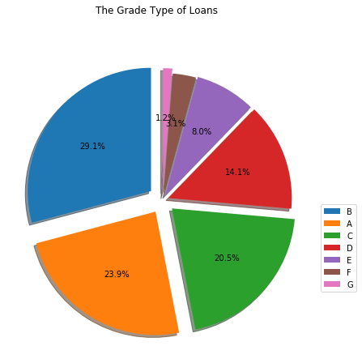

```python
fig, ax = plt.subplots(figsize=(8,7))
explode = (0.12,0.11,0.10,0.05,0.04,0.03,0.07)
ax.pie(loan_grades, labels = None, autopct='%1.1f%%', startangle=90, shadow = True, explode = explode)
ax.legend(bbox_to_anchor=(1,0.5), labels=loan_grades.index)
plt.suptitle('The Grade Type of Loans')
```

##### Understanding

It can be seen that out of all the grade type of loans presesnt, grade B has the maximum. Grade F and G have minimum of the data for the loan for the interest rate to paid or the loan not being fulfilled.

###### Graph: 2

```python
loans2.groupby(['int_rate']).grade.value_counts().nlargest(20)
```

```
int_rate  grade
10.99     B        970
11.49     B        837
13.49     C        829
7.51      A        787
7.88      A        742
7.49      A        656
11.71     B        609
9.99      B        607
7.90      A        582
5.42      A        573
11.99     B        535
12.69     B        492
10.37     B        470
6.03      A        447
12.99     C        446
8.49      A        445
12.42     B        443
10.65     B        435
5.79      A        410
8.90      A        402
Name: grade, dtype: int64
```

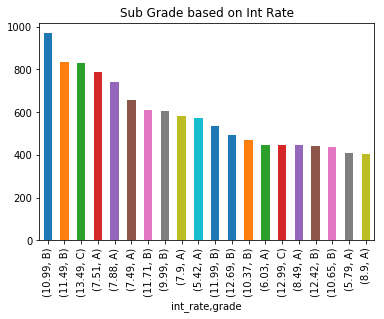

```python
loans2.groupby(['int_rate']).grade.value_counts().nlargest(20)\
.plot(kind = 'bar',title = 'Sub Grade based on Int Rate')
```

##### Understanding

it can be seen that grade B has the maximum loan type where the loan interest type can be change and to be paid. it can be seen interest has an affect by the grade type.

###### Graph: 3

```python
loan_sub_grades= loans2.groupby(['int_rate']).sub_grade.value_counts().nlargest(20)
loan_sub_grades
```

```
int_rate  sub_grade
11.49     B4           837
7.88      A5           742
10.99     B3           721
7.49      A4           656
11.71     B3           609
7.90      A4           582
5.42      A1           573
11.99     B5           535
12.69     B5           492
7.51      A4           484
10.37     B3           470
6.03      A1           447
12.99     C1           446
8.49      A5           445
12.42     B4           443
10.65     B2           435
13.49     C1           417
          C2           412
5.79      A2           410
8.90      A5           402
Name: sub_grade, dtype: int64
```

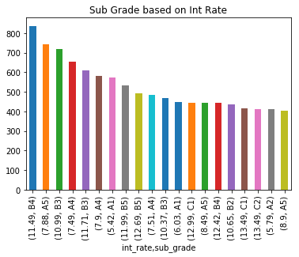

```python
loan_sub_grades.plot(kind = 'bar',title = 'Sub Grade based on Int Rate')
```

##### Understanding

It can be seen most of the sub grade is B4 where the it is affected by the interest rate. the interest rate is affected by sub grade to be paid by a person when required.

```python
test=loans2.groupby(['grade','sub_grade'],as_index=False).int_rate.mean()
test
```

|  | grade | sub_grade | int_rate |
| --- | --- | --- | --- |
| 0 | A | A1 | 5.808897 |
| 1 | A | A2 | 6.387855 |
| 2 | A | A3 | 7.169347 |
| 3 | A | A4 | 7.665215 |
| 4 | A | A5 | 8.267214 |
| 5 | B | B1 | 9.998236 |
| 6 | B | B2 | 10.486077 |
| 7 | B | B3 | 10.983310 |
| 8 | B | B4 | 11.399876 |
| 9 | B | B5 | 11.770078 |
| 10 | C | C1 | 12.818061 |
| 11 | C | C2 | 13.296296 |
| 12 | C | C3 | 13.596966 |
| 13 | C | C4 | 13.966825 |
| 14 | C | C5 | 14.415577 |
| 15 | D | D1 | 14.730313 |
| 16 | D | D2 | 15.263966 |
| 17 | D | D3 | 15.633775 |
| 18 | D | D4 | 15.955044 |
| 19 | D | D5 | 16.414882 |
| 20 | E | E1 | 16.777240 |
| 21 | E | E2 | 17.091656 |
| 22 | E | E3 | 17.421647 |
| 23 | E | E4 | 17.829783 |
| 24 | E | E5 | 18.329599 |
| 25 | F | F1 | 18.756020 |
| 26 | F | F2 | 18.956753 |
| 27 | F | F3 | 19.465381 |
| 28 | F | F4 | 19.829052 |
| 29 | F | F5 | 20.099740 |
| 30 | G | G1 | 20.390426 |
| 31 | G | G2 | 20.423178 |
| 32 | G | G3 | 20.605823 |
| 33 | G | G4 | 20.566970 |
| 34 | G | G5 | 20.310698 |

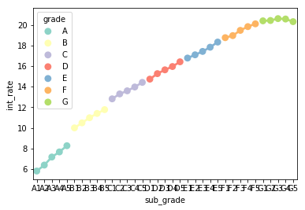

```python
sns.pointplot(x="sub_grade", y="int_rate", hue="grade",data=test, palette="Set3")
```

###### Graph: 4

```python
settlement_pay=loans2.groupby(['settlement_status','int_rate']).settlement_amount.mean().nlargest(25)
settlement_pay
```

```
settlement_status  int_rate
ACTIVE             20.03       14798.200
COMPLETE           22.35       14161.280
                   20.77       12426.220
                   12.18       12390.990
                   17.51       12000.000
                   14.79       11000.000
                   13.06       10412.000
                   15.58       10021.060
                   21.67        9222.075
BROKEN             12.42        9000.000
COMPLETE           14.26        8000.000
                   20.62        7420.480
BROKEN             16.82        7262.260
COMPLETE           12.42        7195.000
                   11.03        7000.000
                   19.74        6682.000
BROKEN             17.49        6500.000
COMPLETE           12.84        6500.000
                   20.25        6500.000
                   16.40        6400.000
                   18.78        6391.610
                   19.03        6336.760
ACTIVE             16.82        6323.000
COMPLETE           11.99        6304.525
                   23.52        6003.000
Name: settlement_amount, dtype: float64
```

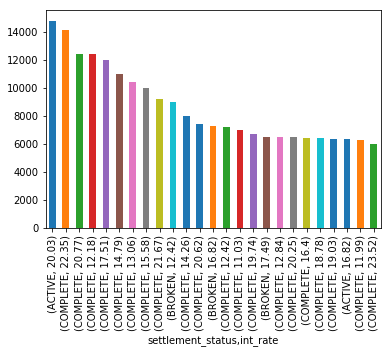

```python
settlement_pay.plot.bar()
```

##### Understanding

THis bar grahp shows how the settlement amount is affected by the status of settlement and how much interest rate is affecting the highest settlement amount. Though it can be seen that most of the settlement amount is complete even though some of the interest rate is above 20%.

###### Graph: 5

```python
loans2.corr()
```

|  | loan_amnt | funded_amnt_inv | int_rate | term | installment | settlement_amount |
| --- | --- | --- | --- | --- | --- | --- |
| loan_amnt | 1.000000 | 0.929598 | 0.292346 | 0.355647 | 0.930869 | 0.635432 |
| funded_amnt_inv | 0.929598 | 1.000000 | 0.279992 | 0.363846 | 0.890148 | 0.524229 |
| int_rate | 0.292346 | 0.279992 | 1.000000 | 0.428649 | 0.271433 | 0.325898 |
| term | 0.355647 | 0.363846 | 0.428649 | 1.000000 | 0.097614 | 0.292471 |
| installment | 0.930869 | 0.890148 | 0.271433 | 0.097614 | 1.000000 | 0.576999 |
| settlement_amount | 0.635432 | 0.524229 | 0.325898 | 0.292471 | 0.576999 | 1.000000 |

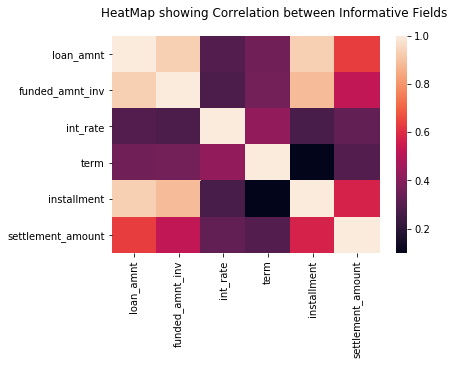

```python
sns.heatmap(loans2.corr());
plt.suptitle('HeatMap showing Correlation between Informative Fields')
```

##### Understanding

it can be seen that int rate has positive correlation to various fields though by not too much as the range mostly range between 0.2 and 0.4, which is not too much.

###### Graph: 6

```python
loan_int=loans2.groupby('term').int_rate.mean()
loan_int
```

```
term
36.0    11.226254
60.0    14.855945
Name: int_rate, dtype: float64
```

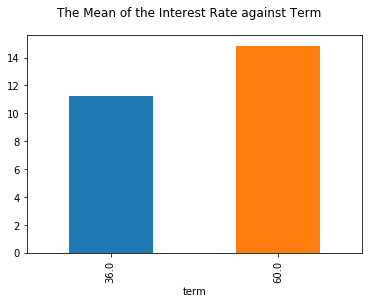

```python
loan_int.plot.bar(stacked=True)
plt.suptitle('The Mean of the Interest Rate against Term')
```

##### Understanding

It can be be seen that the mean of interest is more on the as the term increases.

###### Graph: 7

7(a)

```python
installments1=loans2[loans2['int_rate'] != 6.03].installment
installments1
```

```
0        162.87
1         59.83
2         84.33
3        339.31
4         67.79
5        156.46
6        170.08
7        109.43
8        152.39
9        121.45
10       153.45
11       402.54
12       305.38
13        96.68
14       325.74
```

[output cut: 47 more lines]

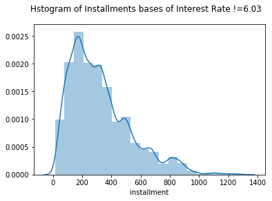

```python
sns.distplot(installments1, bins = 20)
plt.suptitle('Hstogram of Installments bases of Interest Rate !=6.03')
```

7(b)

```python
installments2=loans2[loans2['int_rate'] != 11.71].installment
installments2
```

```
0        162.87
1         59.83
2         84.33
3        339.31
4         67.79
5        156.46
6        170.08
7        109.43
8        152.39
9        121.45
10       153.45
11       402.54
12       305.38
13        96.68
14       325.74
```

[output cut: 47 more lines]

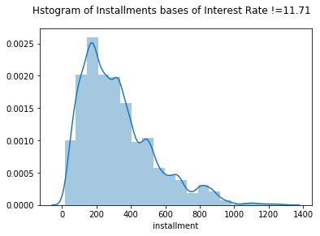

```python
sns.distplot(installments2, bins = 20)
plt.suptitle('Hstogram of Installments bases of Interest Rate !=11.71')
```

#### Conclusion

In conclusion, the insterest rate is affected by or has affect on fields such settlement amount, the grades and sub grades. There are other fields that affected in correlation to interest rate but it may not by too much as see in the heat map.